# Pandas part III - Exercise solutions

```python
import warnings
warnings.filterwarnings('ignore')

import pandas as pd
import numpy as np
import matplotlib.pyplot as plt
import seaborn as sns
```

### Exercise 1

We will work with the `tilapia_pheno.txt` file.

- Sort the dataframe in terms of `Weight_final` and `Weight_initial` from higher to lower.
- Sort the dataframe based on the difference between `Weight_final` and `Weight_initial` from lower to higher.
- Calculate how many animals are in each Pond of each Location. Also calculate the mean `Weight_final` and `Length_final` and the corresponding standard deviations.
- Calculate how many animals of each line are in each happa of each pond and location. For all numeric columns estimate the mean, max, min and standard deviation.

```python
til_pheno = pd.read_csv('tilapia_pheno.txt', sep="\t", na_values='0')
til_pheno
```

|  | PIT_TAG | Location | Line | Family | Age | Pond | Happa | Weight_initial | Weight_final | Length_initial | Length_final | AGR |
| --- | --- | --- | --- | --- | --- | --- | --- | --- | --- | --- | --- | --- |
| 0 | 10977965 | Kunduchi | Wami | 1 | 154 | 2 | 3.0 | 84.30 | 201.50 | 14.2 | 18.0 | 0.761039 |
| 1 | 10978207 | Kunduchi | Wami | 1 | 154 | 1 | 2.0 | 67.80 | NaN | 13.4 | NaN | -0.440260 |
| 2 | 10978378 | Kunduchi | Wami | 1 | 154 | 2 | 4.0 | 103.94 | 225.90 | 14.4 | 18.5 | 0.791948 |
| 3 | 10978460 | Kunduchi | Wami | 1 | 154 | 1 | 1.0 | 84.85 | 239.20 | 14.5 | 19.9 | 1.002273 |
| 4 | 10977732 | Kunduchi | Wami | 1 | 154 | 1 | 1.0 | 78.29 | 195.60 | 14.0 | 19.0 | 0.761753 |
| ... | ... | ... | ... | ... | ... | ... | ... | ... | ... | ... | ... | ... |
| 1747 | 10978369 | Pangani | Ruaha | 35 | 133 | 1 | 1.0 | 26.93 | 86.12 | 9.4 | 13.8 | 0.445038 |
| 1748 | 10978013 | Pangani | Ruaha | 35 | 133 | 2 | 3.0 | 18.02 | NaN | 8.6 | NaN | -0.135489 |
| 1749 | 10978579 | Pangani | Ruaha | 35 | 133 | 2 | 3.0 | 46.97 | 101.54 | 11.0 | 14.0 | 0.410301 |
| 1750 | 10977708 | Pangani | Ruaha | 35 | 133 | 1 | 1.0 | 39.83 | 64.24 | 10.7 | 13.4 | 0.183534 |
| 1751 | 10977975 | Pangani | Ruaha | 35 | 133 | 1 | 2.0 | 32.14 | 57.24 | 10.0 | 12.0 | 0.188722 |

1752 rows × 12 columns

```python
til_pheno.info()
```

```
<class 'pandas.core.frame.DataFrame'>
RangeIndex: 1752 entries, 0 to 1751
Data columns (total 12 columns):
 #   Column          Non-Null Count  Dtype
---  ------          --------------  -----
 0   PIT_TAG         1752 non-null   int64
 1   Location        1752 non-null   object
 2   Line            1752 non-null   object
 3   Family          1752 non-null   int64
 4   Age             1752 non-null   int64
 5   Pond            1752 non-null   int64
 6   Happa           1751 non-null   float64
 7   Weight_initial  1752 non-null   float64
 8   Weight_final    1393 non-null   float64
 9   Length_initial  1752 non-null   float64
 10  Length_final    1393 non-null   float64
 11  AGR             1752 non-null   float64
dtypes: float64(6), int64(4), object(2)
memory usage: 164.4+ KB
```

```python
til_pheno[['PIT_TAG','Family','Age','Pond','Happa']] = til_pheno[
    ['PIT_TAG','Family','Age','Pond','Happa']].astype(str)
```

```python
til_pheno['PIT_TAG'].duplicated().any()
```

```
True
```

```python
til_pheno.drop_duplicates(subset='PIT_TAG',inplace=True)
```

```python
til_pheno.info()
```

```
<class 'pandas.core.frame.DataFrame'>
Int64Index: 1731 entries, 0 to 1751
Data columns (total 12 columns):
 #   Column          Non-Null Count  Dtype
---  ------          --------------  -----
 0   PIT_TAG         1731 non-null   object
 1   Location        1731 non-null   object
 2   Line            1731 non-null   object
 3   Family          1731 non-null   object
 4   Age             1731 non-null   object
 5   Pond            1731 non-null   object
 6   Happa           1731 non-null   object
 7   Weight_initial  1731 non-null   float64
 8   Weight_final    1378 non-null   float64
 9   Length_initial  1731 non-null   float64
 10  Length_final    1378 non-null   float64
 11  AGR             1731 non-null   float64
dtypes: float64(5), object(7)
memory usage: 175.8+ KB
```

Sort the dataframe in terms of `Weight_final` and `Weight_initial` from higher to lower.

```python
til_pheno.sort_values(['Weight_final','Weight_initial'],ascending=False)
```

|  | PIT_TAG | Location | Line | Family | Age | Pond | Happa | Weight_initial | Weight_final | Length_initial | Length_final | AGR |
| --- | --- | --- | --- | --- | --- | --- | --- | --- | --- | --- | --- | --- |
| 910 | 10976502 | Pangani | Wami | 2 | 154 | 1 | 2.0 | 78.56 | 325.40 | 13.6 | 21.0 | 1.602857 |
| 879 | 10975925 | Pangani | Wami | 1 | 154 | 2 | 4.0 | 63.61 | 303.81 | 13.0 | 20.3 | 1.559740 |
| 903 | 10975720 | Pangani | Wami | 2 | 154 | 1 | 1.0 | 34.03 | 300.29 | 14.2 | 20.3 | 1.728961 |
| 913 | 10975646 | Pangani | Wami | 2 | 154 | 1 | 1.0 | 69.53 | 295.08 | 13.5 | 20.5 | 1.464610 |
| 882 | 10975850 | Pangani | Wami | 1 | 154 | 2 | 3.0 | 72.34 | 294.63 | 12.9 | 20.0 | 1.443442 |
| ... | ... | ... | ... | ... | ... | ... | ... | ... | ... | ... | ... | ... |
| 658 | 10974638 | Kunduchi | Bwawani | 25 | 154 | 1 | 1.0 | 10.51 | NaN | 7.0 | NaN | -0.068247 |
| 869 | 10977199 | Kunduchi | Ruaha | 35 | 133 | 1 | 1.0 | 9.80 | NaN | 6.9 | NaN | -0.073684 |
| 847 | 10977491 | Kunduchi | Ruaha | 34 | 133 | 2 | 4.0 | 9.78 | NaN | 6.6 | NaN | -0.073534 |
| 1719 | 10978580 | Pangani | Ruaha | 33 | 140 | 1 | 1.0 | 9.64 | NaN | 6.5 | NaN | -0.068857 |
| 848 | 10977149 | Kunduchi | Ruaha | 34 | 133 | 1 | 1.0 | 9.20 | NaN | 6.7 | NaN | -0.069173 |

1731 rows × 12 columns

Sort the dataframe based on the difference between `Weight_final` and `Weight_initial` from lower to higher.

```python
til_pheno['Weight_diff'] = til_pheno['Weight_final'] - til_pheno['Weight_initial']
```

```python
til_pheno.sort_values('Weight_diff')
```

|  | PIT_TAG | Location | Line | Family | Age | Pond | Happa | Weight_initial | Weight_final | Length_initial | Length_final | AGR | Weight_diff |
| --- | --- | --- | --- | --- | --- | --- | --- | --- | --- | --- | --- | --- | --- |
| 148 | 10975153 | Kunduchi | Chemchem | 6 | 154 | 1 | 1.0 | 74.86 | 54.30 | 12.7 | 14.0 | -0.133506 | -20.56 |
| 307 | 10974755 | Kunduchi | Mindu | 12 | 140 | 1 | 1.0 | 58.26 | 59.20 | 11.7 | 12.0 | 0.006714 | 0.94 |
| 637 | 10975011 | Kunduchi | Bwawani | 24 | 154 | 2 | 4.0 | 113.06 | 115.90 | 15.0 | 15.2 | 0.018442 | 2.84 |
| 1301 | 10975855 | Pangani | Kibasira | 17 | 154 | 2 | 3.0 | 29.34 | 33.40 | 9.2 | 10.7 | 0.026364 | 4.06 |
| 1278 | 10976548 | Pangani | Utete | 16 | 154 | 1 | 2.0 | 69.41 | 73.76 | 12.6 | 14.0 | 0.028247 | 4.35 |
| ... | ... | ... | ... | ... | ... | ... | ... | ... | ... | ... | ... | ... | ... |
| 1734 | 10978538 | Pangani | Ruaha | 34 | 133 | 1 | 2.0 | 13.78 | NaN | 7.9 | NaN | -0.103609 | NaN |
| 1737 | 10978178 | Pangani | Ruaha | 34 | 133 | 1 | 2.0 | 10.69 | NaN | 6.9 | NaN | -0.080376 | NaN |
| 1741 | 10977748 | Pangani | Ruaha | 35 | 133 | 2 | 4.0 | 22.35 | NaN | 8.9 | NaN | -0.168045 | NaN |
| 1742 | 10978899 | Pangani | Ruaha | 35 | 133 | 2 | 4.0 | 39.64 | NaN | 10.8 | NaN | -0.298045 | NaN |
| 1748 | 10978013 | Pangani | Ruaha | 35 | 133 | 2 | 3.0 | 18.02 | NaN | 8.6 | NaN | -0.135489 | NaN |

1731 rows × 13 columns

```python
til_pheno.groupby(['Location','Pond']).size()
```

```
Location  Pond
Kunduchi  1       433
          2       434
Pangani   1       427
          2       437
dtype: int64
```

```python
til_pheno.groupby(['Location','Pond'])[['Weight_final','Length_final']].aggregate(mean=('Weight_final',np.nanmean),std=('Length_final',np.nanstd))
```

| Location | Pond | mean | std |
| --- | --- | --- | --- |
| Kunduchi | 1 | 108.895906 | 2.359917 |
|  | 2 | 100.449311 | 2.156706 |
| Pangani | 1 | 125.206250 | 2.658466 |
|  | 2 | 121.840870 | 2.476626 |

```python
til_pheno.groupby(['Location','Pond','Happa']).size()
```

```
Location  Pond  Happa
Kunduchi  1     1.0      221
                2.0      210
                3.0        1
                4.0        1
          2     2.0        3
                3.0      216
                4.0      215
Pangani   1     1.0      220
                2.0      207
          2     3.0      218
                4.0      218
                nan        1
dtype: int64
```

```python
til_pheno.groupby(['Location','Pond','Happa']).aggregate([np.nanmean,np.std,'max','min'])
```

| Location | Pond | Happa | PIT_TAG nanmean | PIT_TAG std | PIT_TAG max | PIT_TAG min | Family nanmean | Family std | Family max | Family min | Age nanmean | Age std | ... | Length_final max | Length_final min | AGR nanmean | AGR std | AGR max | AGR min | Weight_diff nanmean | Weight_diff std | Weight_diff max | Weight_diff min |
| --- | --- | --- | --- | --- | --- | --- | --- | --- | --- | --- | --- | --- | --- | --- | --- | --- | --- | --- | --- | --- | --- | --- | --- |
| Kunduchi | 1 | 1.0 | inf | 1221.513742 | 10978612 | 10974638 | inf | 9.997848 | 9 | 1 | inf | 9.615981 | ... | 20.0 | 9.6 | 0.288007 | 0.379773 | 1.187338 | -0.687338 | 64.723529 | 34.770111 | 182.85 | -20.56 |
|  |  | 2.0 | inf | 1238.231727 | 10979553 | 10974645 | inf | 10.015663 | 9 | 1 | inf | 9.626709 | ... | 19.0 | 9.6 | 0.298549 | 0.332479 | 0.983000 | -0.504000 | 60.260760 | 32.616822 | 145.58 | 7.20 |
|  |  | 3.0 | 1.097523e+07 | NaN | 10975233 | 10975233 | 1.500000e+01 | NaN | 15 | 15 | 1.540000e+02 | NaN | ... | 13.0 | 13.0 | 0.350779 | NaN | 0.350779 | 0.350779 | 54.020000 | NaN | 54.02 | 54.02 |
|  |  | 4.0 | 1.097697e+07 | NaN | 10976971 | 10976971 | 3.000000e+01 | NaN | 30 | 30 | 1.330000e+02 | NaN | ... | NaN | NaN | -0.223985 | NaN | -0.223985 | -0.223985 | NaN | NaN | NaN | NaN |
|  | 2 | 2.0 | 3.658482e+22 | 381.744679 | 10975446 | 10974763 | 4.043767e+04 | 0.577350 | 13 | 12 | 4.671805e+07 | 8.082904 | ... | 19.0 | 13.0 | 0.217162 | 0.163033 | 0.396357 | 0.077597 | 31.593333 | 22.079426 | 55.49 | 11.95 |
|  |  | 3.0 | inf | 1233.243486 | 10978630 | 10974632 | inf | 9.933915 | 9 | 1 | inf | 9.673898 | ... | 18.3 | 9.3 | 0.311289 | 0.277172 | 1.067143 | -0.499774 | 54.725737 | 28.324692 | 149.40 | 6.02 |
|  |  | 4.0 | inf | 1185.715550 | 10978629 | 10974634 | inf | 9.900116 | 9 | 1 | inf | 9.574097 | ... | 19.1 | 9.1 | 0.229537 | 0.311210 | 1.117820 | -0.526494 | 51.487824 | 26.958518 | 148.67 | 2.84 |
| Pangani | 1 | 1.0 | inf | 1017.422641 | 10978620 | 10975635 | inf | 9.998273 | 9 | 1 | inf | 9.669997 | ... | 21.5 | 9.0 | 0.336679 | 0.489260 | 1.728961 | -0.814586 | 75.838647 | 53.492520 | 266.26 | 5.95 |
|  |  | 2.0 | inf | 1071.646945 | 10978610 | 10973214 | inf | 9.908384 | 9 | 1 | inf | 9.666931 | ... | 21.0 | 9.3 | 0.330108 | 0.457574 | 1.886391 | -0.573357 | 74.735000 | 47.914484 | 250.89 | 4.35 |
|  | 2 | 3.0 | inf | 1336.705955 | 10988600 | 10973049 | inf | 9.842617 | 9 | 1 | inf | 9.592558 | ... | 20.5 | 10.0 | 0.345449 | 0.491681 | 1.471805 | -0.709699 | 79.110479 | 48.069976 | 222.29 | 4.06 |
|  |  | 4.0 | inf | 1047.155812 | 10978899 | 10973583 | inf | 10.002879 | 9 | 1 | inf | 9.648598 | ... | 21.5 | 9.7 | 0.370325 | 0.441597 | 1.559740 | -0.689429 | 75.645281 | 44.766840 | 240.20 | 7.96 |
|  |  | nan | 1.097622e+07 | NaN | 10976217 | 10976217 | 1.600000e+01 | NaN | 16 | 16 | 1.540000e+02 | NaN | ... | NaN | NaN | -0.742013 | NaN | -0.742013 | -0.742013 | NaN | NaN | NaN | NaN |

12 rows × 36 columns

### Exercise 2

We will work with the `tilapia_pedigree.txt` and the `tilapia_pheno.txt` files.

- Perform a left, right and an outer merge
- Create a new dataframe of the `tilapia_pedigree` file that does not contain the animals that are in the `tilapia_pheno` file.
- Create a new dataframe from the `tilapia_pheno` that contains only the animals that are in the `tilapia_pedigree`. Proceed by calculating the mean, max, min and standard deviation of the difference between `Weight_final` and `Weight_initial` for each line on both locations.

```python
til_ped = pd.read_csv('tilapia_pedigree.txt', sep="\t")
til_ped
```

|  | Id | Sire | Dam | Line |
| --- | --- | --- | --- | --- |
| 0 | 10977965 | Sire_1 | Dam_1 | Wami |
| 1 | 10978207 | Sire_1 | Dam_1 | Wami |
| 2 | 10978378 | Sire_1 | Dam_1 | Wami |
| 3 | 10978460 | Sire_1 | Dam_1 | Wami |
| 4 | 10977732 | Sire_1 | Dam_1 | Wami |
| ... | ... | ... | ... | ... |
| 1733 | 10278259 | Sire_34 | Dam_34 | Ruaha |
| 1734 | 10278538 | Sire_34 | Dam_34 | Ruaha |
| 1735 | 10278603 | Sire_34 | Dam_34 | Ruaha |
| 1736 | 10277914 | Sire_34 | Dam_34 | Ruaha |
| 1737 | 10278178 | Sire_34 | Dam_34 | Ruaha |

1738 rows × 4 columns

```python
til_ped['Id'].duplicated().any()
```

```
True
```

```python
til_ped.drop_duplicates(subset='Id',inplace=True)
```

```python
til_ped['Id'].duplicated().any()
```

```
False
```

```python
til_ped.info()
```

```
<class 'pandas.core.frame.DataFrame'>
Int64Index: 1718 entries, 0 to 1737
Data columns (total 4 columns):
 #   Column  Non-Null Count  Dtype
---  ------  --------------  -----
 0   Id      1718 non-null   int64
 1   Sire    1718 non-null   object
 2   Dam     1718 non-null   object
 3   Line    1718 non-null   object
dtypes: int64(1), object(3)
memory usage: 67.1+ KB
```

```python
til_ped['Id'] = til_ped['Id'].astype(str)
```

Perform a left, right, an outer and an inner merge

```python
pd.merge(til_ped, til_pheno, left_on='Id', right_on='PIT_TAG', how='left')
```

|  | Id | Sire | Dam | Line_x | PIT_TAG | Location | Line_y | Family | Age | Pond | Happa | Weight_initial | Weight_final | Length_initial | Length_final | AGR | Weight_diff |
| --- | --- | --- | --- | --- | --- | --- | --- | --- | --- | --- | --- | --- | --- | --- | --- | --- | --- |
| 0 | 10977965 | Sire_1 | Dam_1 | Wami | 10977965 | Kunduchi | Wami | 1 | 154 | 2 | 3.0 | 84.30 | 201.5 | 14.2 | 18.0 | 0.761039 | 117.20 |
| 1 | 10978207 | Sire_1 | Dam_1 | Wami | 10978207 | Kunduchi | Wami | 1 | 154 | 1 | 2.0 | 67.80 | NaN | 13.4 | NaN | -0.440260 | NaN |
| 2 | 10978378 | Sire_1 | Dam_1 | Wami | 10978378 | Kunduchi | Wami | 1 | 154 | 2 | 4.0 | 103.94 | 225.9 | 14.4 | 18.5 | 0.791948 | 121.96 |
| 3 | 10978460 | Sire_1 | Dam_1 | Wami | 10978460 | Kunduchi | Wami | 1 | 154 | 1 | 1.0 | 84.85 | 239.2 | 14.5 | 19.9 | 1.002273 | 154.35 |
| 4 | 10977732 | Sire_1 | Dam_1 | Wami | 10977732 | Kunduchi | Wami | 1 | 154 | 1 | 1.0 | 78.29 | 195.6 | 14.0 | 19.0 | 0.761753 | 117.31 |
| ... | ... | ... | ... | ... | ... | ... | ... | ... | ... | ... | ... | ... | ... | ... | ... | ... | ... |
| 1713 | 10278259 | Sire_34 | Dam_34 | Ruaha | NaN | NaN | NaN | NaN | NaN | NaN | NaN | NaN | NaN | NaN | NaN | NaN | NaN |
| 1714 | 10278538 | Sire_34 | Dam_34 | Ruaha | NaN | NaN | NaN | NaN | NaN | NaN | NaN | NaN | NaN | NaN | NaN | NaN | NaN |
| 1715 | 10278603 | Sire_34 | Dam_34 | Ruaha | NaN | NaN | NaN | NaN | NaN | NaN | NaN | NaN | NaN | NaN | NaN | NaN | NaN |
| 1716 | 10277914 | Sire_34 | Dam_34 | Ruaha | NaN | NaN | NaN | NaN | NaN | NaN | NaN | NaN | NaN | NaN | NaN | NaN | NaN |
| 1717 | 10278178 | Sire_34 | Dam_34 | Ruaha | NaN | NaN | NaN | NaN | NaN | NaN | NaN | NaN | NaN | NaN | NaN | NaN | NaN |

1718 rows × 17 columns

```python
pd.merge(til_ped,til_pheno,left_on='Id',right_on='PIT_TAG', how='right')
```

|  | Id | Sire | Dam | Line_x | PIT_TAG | Location | Line_y | Family | Age | Pond | Happa | Weight_initial | Weight_final | Length_initial | Length_final | AGR | Weight_diff |
| --- | --- | --- | --- | --- | --- | --- | --- | --- | --- | --- | --- | --- | --- | --- | --- | --- | --- |
| 0 | 10977965 | Sire_1 | Dam_1 | Wami | 10977965 | Kunduchi | Wami | 1 | 154 | 2 | 3.0 | 84.30 | 201.50 | 14.2 | 18.0 | 0.761039 | 117.20 |
| 1 | 10978207 | Sire_1 | Dam_1 | Wami | 10978207 | Kunduchi | Wami | 1 | 154 | 1 | 2.0 | 67.80 | NaN | 13.4 | NaN | -0.440260 | NaN |
| 2 | 10978378 | Sire_1 | Dam_1 | Wami | 10978378 | Kunduchi | Wami | 1 | 154 | 2 | 4.0 | 103.94 | 225.90 | 14.4 | 18.5 | 0.791948 | 121.96 |
| 3 | 10978460 | Sire_1 | Dam_1 | Wami | 10978460 | Kunduchi | Wami | 1 | 154 | 1 | 1.0 | 84.85 | 239.20 | 14.5 | 19.9 | 1.002273 | 154.35 |
| 4 | 10977732 | Sire_1 | Dam_1 | Wami | 10977732 | Kunduchi | Wami | 1 | 154 | 1 | 1.0 | 78.29 | 195.60 | 14.0 | 19.0 | 0.761753 | 117.31 |
| ... | ... | ... | ... | ... | ... | ... | ... | ... | ... | ... | ... | ... | ... | ... | ... | ... | ... |
| 1726 | NaN | NaN | NaN | NaN | 10978369 | Pangani | Ruaha | 35 | 133 | 1 | 1.0 | 26.93 | 86.12 | 9.4 | 13.8 | 0.445038 | 59.19 |
| 1727 | NaN | NaN | NaN | NaN | 10978013 | Pangani | Ruaha | 35 | 133 | 2 | 3.0 | 18.02 | NaN | 8.6 | NaN | -0.135489 | NaN |
| 1728 | NaN | NaN | NaN | NaN | 10978579 | Pangani | Ruaha | 35 | 133 | 2 | 3.0 | 46.97 | 101.54 | 11.0 | 14.0 | 0.410301 | 54.57 |
| 1729 | NaN | NaN | NaN | NaN | 10977708 | Pangani | Ruaha | 35 | 133 | 1 | 1.0 | 39.83 | 64.24 | 10.7 | 13.4 | 0.183534 | 24.41 |
| 1730 | NaN | NaN | NaN | NaN | 10977975 | Pangani | Ruaha | 35 | 133 | 1 | 2.0 | 32.14 | 57.24 | 10.0 | 12.0 | 0.188722 | 25.10 |

1731 rows × 17 columns

```python
pd.merge(til_ped,til_pheno,left_on='Id',right_on='PIT_TAG', how='outer')
```

|  | Id | Sire | Dam | Line_x | PIT_TAG | Location | Line_y | Family | Age | Pond | Happa | Weight_initial | Weight_final | Length_initial | Length_final | AGR | Weight_diff |
| --- | --- | --- | --- | --- | --- | --- | --- | --- | --- | --- | --- | --- | --- | --- | --- | --- | --- |
| 0 | 10977965 | Sire_1 | Dam_1 | Wami | 10977965 | Kunduchi | Wami | 1 | 154 | 2 | 3.0 | 84.30 | 201.50 | 14.2 | 18.0 | 0.761039 | 117.20 |
| 1 | 10978207 | Sire_1 | Dam_1 | Wami | 10978207 | Kunduchi | Wami | 1 | 154 | 1 | 2.0 | 67.80 | NaN | 13.4 | NaN | -0.440260 | NaN |
| 2 | 10978378 | Sire_1 | Dam_1 | Wami | 10978378 | Kunduchi | Wami | 1 | 154 | 2 | 4.0 | 103.94 | 225.90 | 14.4 | 18.5 | 0.791948 | 121.96 |
| 3 | 10978460 | Sire_1 | Dam_1 | Wami | 10978460 | Kunduchi | Wami | 1 | 154 | 1 | 1.0 | 84.85 | 239.20 | 14.5 | 19.9 | 1.002273 | 154.35 |
| 4 | 10977732 | Sire_1 | Dam_1 | Wami | 10977732 | Kunduchi | Wami | 1 | 154 | 1 | 1.0 | 78.29 | 195.60 | 14.0 | 19.0 | 0.761753 | 117.31 |
| ... | ... | ... | ... | ... | ... | ... | ... | ... | ... | ... | ... | ... | ... | ... | ... | ... | ... |
| 1778 | NaN | NaN | NaN | NaN | 10978369 | Pangani | Ruaha | 35 | 133 | 1 | 1.0 | 26.93 | 86.12 | 9.4 | 13.8 | 0.445038 | 59.19 |
| 1779 | NaN | NaN | NaN | NaN | 10978013 | Pangani | Ruaha | 35 | 133 | 2 | 3.0 | 18.02 | NaN | 8.6 | NaN | -0.135489 | NaN |
| 1780 | NaN | NaN | NaN | NaN | 10978579 | Pangani | Ruaha | 35 | 133 | 2 | 3.0 | 46.97 | 101.54 | 11.0 | 14.0 | 0.410301 | 54.57 |
| 1781 | NaN | NaN | NaN | NaN | 10977708 | Pangani | Ruaha | 35 | 133 | 1 | 1.0 | 39.83 | 64.24 | 10.7 | 13.4 | 0.183534 | 24.41 |
| 1782 | NaN | NaN | NaN | NaN | 10977975 | Pangani | Ruaha | 35 | 133 | 1 | 2.0 | 32.14 | 57.24 | 10.0 | 12.0 | 0.188722 | 25.10 |

1783 rows × 17 columns

```python
pd.merge(til_ped, til_pheno, left_on='Id', right_on='PIT_TAG', how='inner')
```

|  | Id | Sire | Dam | Line_x | PIT_TAG | Location | Line_y | Family | Age | Pond | Happa | Weight_initial | Weight_final | Length_initial | Length_final | AGR | Weight_diff |
| --- | --- | --- | --- | --- | --- | --- | --- | --- | --- | --- | --- | --- | --- | --- | --- | --- | --- |
| 0 | 10977965 | Sire_1 | Dam_1 | Wami | 10977965 | Kunduchi | Wami | 1 | 154 | 2 | 3.0 | 84.30 | 201.50 | 14.2 | 18.0 | 0.761039 | 117.20 |
| 1 | 10978207 | Sire_1 | Dam_1 | Wami | 10978207 | Kunduchi | Wami | 1 | 154 | 1 | 2.0 | 67.80 | NaN | 13.4 | NaN | -0.440260 | NaN |
| 2 | 10978378 | Sire_1 | Dam_1 | Wami | 10978378 | Kunduchi | Wami | 1 | 154 | 2 | 4.0 | 103.94 | 225.90 | 14.4 | 18.5 | 0.791948 | 121.96 |
| 3 | 10978460 | Sire_1 | Dam_1 | Wami | 10978460 | Kunduchi | Wami | 1 | 154 | 1 | 1.0 | 84.85 | 239.20 | 14.5 | 19.9 | 1.002273 | 154.35 |
| 4 | 10977732 | Sire_1 | Dam_1 | Wami | 10977732 | Kunduchi | Wami | 1 | 154 | 1 | 1.0 | 78.29 | 195.60 | 14.0 | 19.0 | 0.761753 | 117.31 |
| ... | ... | ... | ... | ... | ... | ... | ... | ... | ... | ... | ... | ... | ... | ... | ... | ... | ... |
| 1661 | 10977652 | Sire_33 | Dam_33 | Ruaha | 10977652 | Pangani | Ruaha | 33 | 140 | 1 | 2.0 | 14.16 | NaN | 7.4 | NaN | -0.101143 | NaN |
| 1662 | 10978163 | Sire_33 | Dam_33 | Ruaha | 10978163 | Pangani | Ruaha | 33 | 140 | 1 | 2.0 | 19.81 | 35.08 | 8.5 | 10.3 | 0.109071 | 15.27 |
| 1663 | 10977803 | Sire_33 | Dam_33 | Ruaha | 10977803 | Pangani | Ruaha | 33 | 140 | 2 | 3.0 | 29.27 | 44.71 | 9.7 | 10.5 | 0.110286 | 15.44 |
| 1664 | 10978203 | Sire_33 | Dam_33 | Ruaha | 10978203 | Pangani | Ruaha | 33 | 140 | 2 | 4.0 | 25.55 | 60.01 | 9.0 | 17.7 | 0.246143 | 34.46 |
| 1665 | 10978177 | Sire_33 | Dam_33 | Ruaha | 10978177 | Pangani | Ruaha | 33 | 140 | 1 | 2.0 | 14.40 | NaN | 7.6 | NaN | -0.102857 | NaN |

1666 rows × 17 columns

Create a new dataframe of the tilapia_pedigree file that does not contain the animals that are in the tilapia_pheno file.

```python
out_join = pd.merge(til_ped, til_pheno,
                    left_on='Id', right_on='PIT_TAG', how='outer', indicator=True)
keep_animals = out_join.loc[out_join['_merge'] == 'left_only']['Id']
```

```python
pedigree_only = til_ped[til_ped['Id'].isin(keep_animals)]
pedigree_only
```

|  | Id | Sire | Dam | Line |
| --- | --- | --- | --- | --- |
| 5 | 10978530 | Sire_1 | Dam_1 | Wami |
| 570 | 10475459 | Sire_22 | Dam_22 | Nyamisati |
| 575 | 10374831 | Sire_22 | Dam_22 | Nyamisati |
| 751 | 10277458 | Sire_30 | Dam_30 | Kilola |
| 755 | 10276804 | Sire_30 | Dam_30 | Kilola |
| 1012 | 10277730 | Sire_6 | Dam_6 | Chemchem |
| 1013 | 10277719 | Sire_6 | Dam_6 | Chemchem |
| 1014 | 10278428 | Sire_6 | Dam_6 | Chemchem |
| 1015 | 10277718 | Sire_6 | Dam_6 | Chemchem |
| 1016 | 10277709 | Sire_6 | Dam_6 | Chemchem |
| 1017 | 10277978 | Sire_6 | Dam_6 | Chemchem |
| 1018 | 10277681 | Sire_6 | Dam_6 | Chemchem |
| 1019 | 10277696 | Sire_7 | Dam_7 | Chemchem |
| 1030 | 10278540 | Sire_7 | Dam_7 | Chemchem |
| 1031 | 10277631 | Sire_7 | Dam_7 | Chemchem |
| 1032 | 10277688 | Sire_7 | Dam_7 | Chemchem |
| 1033 | 10278008 | Sire_7 | Dam_7 | Chemchem |
| 1034 | 10278525 | Sire_7 | Dam_7 | Chemchem |
| 1035 | 10277649 | Sire_7 | Dam_7 | Chemchem |
| 1036 | 10277724 | Sire_7 | Dam_7 | Chemchem |
| 1037 | 10278272 | Sire_7 | Dam_7 | Chemchem |
| 1038 | 10277972 | Sire_7 | Dam_7 | Chemchem |
| 1039 | 10278287 | Sire_7 | Dam_7 | Chemchem |
| 1040 | 10278583 | Sire_7 | Dam_7 | Chemchem |
| 1041 | 10278516 | Sire_7 | Dam_7 | Chemchem |
| 1042 | 10278290 | Sire_7 | Dam_7 | Chemchem |
| 1043 | 10278581 | Sire_7 | Dam_7 | Chemchem |
| 1044 | 10278055 | Sire_7 | Dam_7 | Chemchem |
| 1045 | 10277930 | Sire_7 | Dam_7 | Chemchem |
| 1046 | 10277641 | Sire_7 | Dam_7 | Chemchem |
| 1047 | 10278025 | Sire_7 | Dam_7 | Chemchem |
| 1048 | 10278101 | Sire_7 | Dam_7 | Chemchem |
| 1718 | 10278223 | Sire_33 | Dam_33 | Ruaha |
| 1719 | 10278580 | Sire_33 | Dam_33 | Ruaha |
| 1720 | 10277784 | Sire_34 | Dam_34 | Ruaha |
| 1721 | 10278377 | Sire_34 | Dam_34 | Ruaha |
| 1722 | 10277644 | Sire_34 | Dam_34 | Ruaha |
| 1723 | 10278592 | Sire_34 | Dam_34 | Ruaha |
| 1724 | 10278006 | Sire_34 | Dam_34 | Ruaha |
| 1725 | 10278020 | Sire_34 | Dam_34 | Ruaha |
| 1726 | 10278326 | Sire_34 | Dam_34 | Ruaha |
| 1727 | 10278567 | Sire_34 | Dam_34 | Ruaha |
| 1728 | 10278056 | Sire_34 | Dam_34 | Ruaha |
| 1729 | 10278387 | Sire_34 | Dam_34 | Ruaha |
| 1730 | 10277932 | Sire_34 | Dam_34 | Ruaha |
| 1731 | 10278453 | Sire_34 | Dam_34 | Ruaha |
| 1732 | 10278036 | Sire_34 | Dam_34 | Ruaha |
| 1733 | 10278259 | Sire_34 | Dam_34 | Ruaha |
| 1734 | 10278538 | Sire_34 | Dam_34 | Ruaha |
| 1735 | 10278603 | Sire_34 | Dam_34 | Ruaha |
| 1736 | 10277914 | Sire_34 | Dam_34 | Ruaha |
| 1737 | 10278178 | Sire_34 | Dam_34 | Ruaha |

Create a new dataframe from the tilapia_pheno that contains only the animals that are in the tilapia_pedigree. Proceed by calculating the mean, max, min and standard deviation of the difference between Weight_final and Weight_initial for each line on both locations.

```python
keep_pheno = out_join.loc[out_join['_merge'] == 'both']['Id']
len(keep_pheno)
```

```
1666
```

```python
til_pheno_clean = til_pheno[til_pheno['PIT_TAG'].isin(keep_pheno)]
til_pheno_clean
```

|  | PIT_TAG | Location | Line | Family | Age | Pond | Happa | Weight_initial | Weight_final | Length_initial | Length_final | AGR | Weight_diff |
| --- | --- | --- | --- | --- | --- | --- | --- | --- | --- | --- | --- | --- | --- |
| 0 | 10977965 | Kunduchi | Wami | 1 | 154 | 2 | 3.0 | 84.30 | 201.50 | 14.2 | 18.0 | 0.761039 | 117.20 |
| 1 | 10978207 | Kunduchi | Wami | 1 | 154 | 1 | 2.0 | 67.80 | NaN | 13.4 | NaN | -0.440260 | NaN |
| 2 | 10978378 | Kunduchi | Wami | 1 | 154 | 2 | 4.0 | 103.94 | 225.90 | 14.4 | 18.5 | 0.791948 | 121.96 |
| 3 | 10978460 | Kunduchi | Wami | 1 | 154 | 1 | 1.0 | 84.85 | 239.20 | 14.5 | 19.9 | 1.002273 | 154.35 |
| 4 | 10977732 | Kunduchi | Wami | 1 | 154 | 1 | 1.0 | 78.29 | 195.60 | 14.0 | 19.0 | 0.761753 | 117.31 |
| ... | ... | ... | ... | ... | ... | ... | ... | ... | ... | ... | ... | ... | ... |
| 1713 | 10977652 | Pangani | Ruaha | 33 | 140 | 1 | 2.0 | 14.16 | NaN | 7.4 | NaN | -0.101143 | NaN |
| 1714 | 10978163 | Pangani | Ruaha | 33 | 140 | 1 | 2.0 | 19.81 | 35.08 | 8.5 | 10.3 | 0.109071 | 15.27 |
| 1715 | 10977803 | Pangani | Ruaha | 33 | 140 | 2 | 3.0 | 29.27 | 44.71 | 9.7 | 10.5 | 0.110286 | 15.44 |
| 1716 | 10978203 | Pangani | Ruaha | 33 | 140 | 2 | 4.0 | 25.55 | 60.01 | 9.0 | 17.7 | 0.246143 | 34.46 |
| 1717 | 10978177 | Pangani | Ruaha | 33 | 140 | 1 | 2.0 | 14.40 | NaN | 7.6 | NaN | -0.102857 | NaN |

1666 rows × 13 columns

```python
til_pheno_clean['Weight_diff'] = til_pheno_clean['Weight_final'] - til_pheno_clean['Weight_initial']
```

```python
til_pheno_clean
```

|  | PIT_TAG | Location | Line | Family | Age | Pond | Happa | Weight_initial | Weight_final | Length_initial | Length_final | AGR | Weight_diff |
| --- | --- | --- | --- | --- | --- | --- | --- | --- | --- | --- | --- | --- | --- |
| 0 | 10977965 | Kunduchi | Wami | 1 | 154 | 2 | 3.0 | 84.30 | 201.50 | 14.2 | 18.0 | 0.761039 | 117.20 |
| 1 | 10978207 | Kunduchi | Wami | 1 | 154 | 1 | 2.0 | 67.80 | NaN | 13.4 | NaN | -0.440260 | NaN |
| 2 | 10978378 | Kunduchi | Wami | 1 | 154 | 2 | 4.0 | 103.94 | 225.90 | 14.4 | 18.5 | 0.791948 | 121.96 |
| 3 | 10978460 | Kunduchi | Wami | 1 | 154 | 1 | 1.0 | 84.85 | 239.20 | 14.5 | 19.9 | 1.002273 | 154.35 |
| 4 | 10977732 | Kunduchi | Wami | 1 | 154 | 1 | 1.0 | 78.29 | 195.60 | 14.0 | 19.0 | 0.761753 | 117.31 |
| ... | ... | ... | ... | ... | ... | ... | ... | ... | ... | ... | ... | ... | ... |
| 1713 | 10977652 | Pangani | Ruaha | 33 | 140 | 1 | 2.0 | 14.16 | NaN | 7.4 | NaN | -0.101143 | NaN |
| 1714 | 10978163 | Pangani | Ruaha | 33 | 140 | 1 | 2.0 | 19.81 | 35.08 | 8.5 | 10.3 | 0.109071 | 15.27 |
| 1715 | 10977803 | Pangani | Ruaha | 33 | 140 | 2 | 3.0 | 29.27 | 44.71 | 9.7 | 10.5 | 0.110286 | 15.44 |
| 1716 | 10978203 | Pangani | Ruaha | 33 | 140 | 2 | 4.0 | 25.55 | 60.01 | 9.0 | 17.7 | 0.246143 | 34.46 |
| 1717 | 10978177 | Pangani | Ruaha | 33 | 140 | 1 | 2.0 | 14.40 | NaN | 7.6 | NaN | -0.102857 | NaN |

1666 rows × 13 columns

```python
til_pheno_clean.groupby(['Line','Location']).agg(mean=('Weight_diff',np.nanmean),
                                                 std=('Weight_diff',np.nanstd),
                                                 maximum=('Weight_diff', max),
                                                 minimum=('Weight_diff',min))
```

| Line | Location | mean | std | maximum | minimum |
| --- | --- | --- | --- | --- | --- |
| Bwawani | Kunduchi | 41.312338 | 27.307001 | 127.30 | 2.84 |
|  | Pangani | 63.900449 | 39.013021 | 180.44 | 12.83 |
| Chemchem | Kunduchi | 64.696163 | 25.992056 | 119.67 | -20.56 |
|  | Pangani | 88.984516 | 43.264984 | 207.77 | 14.15 |
| Kibasira | Kunduchi | 50.052093 | 22.442169 | 101.17 | 15.20 |
|  | Pangani | 53.559268 | 33.488132 | 126.05 | 4.06 |
| Kilola | Kunduchi | 51.956125 | 22.383172 | 148.67 | 18.49 |
|  | Pangani | 64.820976 | 32.234864 | 141.09 | 10.16 |
| Mindu | Kunduchi | 72.725631 | 31.499939 | 155.39 | 0.94 |
|  | Pangani | 104.769286 | 57.508168 | 250.89 | 15.93 |
| Nyamisati | Kunduchi | 52.819639 | 28.656397 | 135.56 | 7.20 |
|  | Pangani | 80.562316 | 47.667884 | 231.13 | 8.48 |
| Ruaha | Kunduchi | 29.431538 | 13.494098 | 69.92 | 5.94 |
|  | Pangani | 37.063333 | 27.426222 | 135.16 | 11.49 |
| Utete | Kunduchi | 47.651868 | 20.639430 | 116.28 | 7.85 |
|  | Pangani | 63.395341 | 40.130197 | 185.36 | 4.35 |
| Wami | Kunduchi | 85.911647 | 34.519687 | 182.85 | 6.02 |
|  | Pangani | 120.278913 | 54.476103 | 266.26 | 17.37 |

### Exercise 3

We will work with the `variants.txt` file. The dataset contains information about the location of genetic variants across different chromosomes.

- Calculate the number of variants for each chromosome and plot the results in the form of a horizontal bar chart.
- For each chromosome estimate the base distribution of the Reference column. Find out which base is the most common in each chromosome. Do the same for the Alternative column.

```python
variants = pd.read_csv('variants.txt',sep="\t")
variants
```

|  | Chromosome | Position | Id | Reference | Alternative |
| --- | --- | --- | --- | --- | --- |
| 0 | CM007481.1 | 591631 | 47:55:+ | G | A |
| 1 | CM007481.1 | 591712 | 49:76:+ | T | G |
| 2 | CM007481.1 | 695676 | 63:243:+ | C | A |
| 3 | CM007481.1 | 737844 | 68:421:+ | C | T |
| 4 | CM007481.1 | 836337 | 77:72:- | C | T |
| ... | ... | ... | ... | ... | ... |
| 2049 | CM007503.1 | 41718225 | 59156:43:- | G | A |
| 2050 | CM007503.1 | 42064476 | 59169:94:- | C | T |
| 2051 | CM007503.1 | 42829360 | 59203:44:+ | C | T |
| 2052 | CM007503.1 | 43607937 | 59253:61:+ | C | T |
| 2053 | CM007503.1 | 43711517 | 59264:9:- | G | T |

2054 rows × 5 columns

```python
variants.info()
```

```
<class 'pandas.core.frame.DataFrame'>
RangeIndex: 2054 entries, 0 to 2053
Data columns (total 5 columns):
 #   Column       Non-Null Count  Dtype
---  ------       --------------  -----
 0   Chromosome   2054 non-null   object
 1   Position     2054 non-null   int64
 2   Id           2054 non-null   object
 3   Reference    2054 non-null   object
 4   Alternative  2054 non-null   object
dtypes: int64(1), object(4)
memory usage: 80.4+ KB
```

Calculate the number of variants for each chromosome and plot the results in the form of a horizontal bar chart.

```python
variants.groupby('Chromosome').size()
```

```
Chromosome
CM007481.1     99
CM007482.1     97
CM007483.1     17
CM007484.1     38
CM007485.1     88
CM007486.1     73
CM007487.1     96
CM007488.1    157
CM007489.1     90
CM007490.1     60
CM007491.1     71
CM007492.1    103
CM007493.1     78
CM007494.1     89
CM007495.1    103
CM007496.1     87
CM007497.1    110
CM007498.1    130
CM007499.1     95
CM007500.1     91
CM007501.1     86
CM007502.1     84
CM007503.1    112
dtype: int64
```

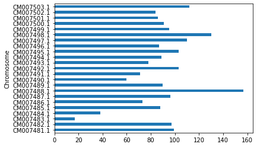

```python
variants.groupby('Chromosome').size().plot(kind='barh')
```

For each chromosome estimate the base distribution of the Reference column. Find out which base is the most common in each chromosome. Do the same for the Alternative column.

```python
ref_common = variants.groupby('Chromosome')['Reference'].value_counts()
```

```python
ref_common
```

```
Chromosome  Reference
CM007481.1  C            30
            G            30
            T            23
            A            16
CM007482.1  G            33
                         ..
CM007502.1  A            14
CM007503.1  C            38
            G            37
            T            19
            A            18
Name: Reference, Length: 92, dtype: int64
```

```python
ref_common_wide = ref_common.unstack()
```

```python
ref_common_wide
```

| Reference Chromosome | A | C | G | T |
| --- | --- | --- | --- | --- |
| CM007481.1 | 16 | 30 | 30 | 23 |
| CM007482.1 | 14 | 25 | 33 | 25 |
| CM007483.1 | 2 | 8 | 4 | 3 |
| CM007484.1 | 6 | 10 | 15 | 7 |
| CM007485.1 | 18 | 28 | 31 | 11 |
| CM007486.1 | 17 | 23 | 21 | 12 |
| CM007487.1 | 18 | 33 | 17 | 28 |
| CM007488.1 | 33 | 56 | 34 | 34 |
| CM007489.1 | 21 | 24 | 25 | 20 |
| CM007490.1 | 10 | 15 | 21 | 14 |
| CM007491.1 | 21 | 18 | 14 | 18 |
| CM007492.1 | 19 | 36 | 25 | 23 |
| CM007493.1 | 10 | 31 | 25 | 12 |
| CM007494.1 | 13 | 28 | 25 | 23 |
| CM007495.1 | 22 | 28 | 29 | 24 |
| CM007496.1 | 13 | 26 | 25 | 23 |
| CM007497.1 | 29 | 27 | 33 | 21 |
| CM007498.1 | 30 | 32 | 41 | 27 |
| CM007499.1 | 18 | 28 | 26 | 23 |
| CM007500.1 | 18 | 29 | 32 | 12 |
| CM007501.1 | 18 | 27 | 22 | 19 |
| CM007502.1 | 14 | 34 | 21 | 15 |
| CM007503.1 | 18 | 38 | 37 | 19 |

```python
ref_common_wide.apply(lambda x: (ref_common_wide.columns[x.argmax()], max(x)), axis=1)
```

```
Chromosome
CM007481.1    (C, 30)
CM007482.1    (G, 33)
CM007483.1     (C, 8)
CM007484.1    (G, 15)
CM007485.1    (G, 31)
CM007486.1    (C, 23)
CM007487.1    (C, 33)
CM007488.1    (C, 56)
CM007489.1    (G, 25)
CM007490.1    (G, 21)
CM007491.1    (A, 21)
CM007492.1    (C, 36)
CM007493.1    (C, 31)
CM007494.1    (C, 28)
CM007495.1    (G, 29)
CM007496.1    (C, 26)
CM007497.1    (G, 33)
CM007498.1    (G, 41)
CM007499.1    (C, 28)
CM007500.1    (G, 32)
CM007501.1    (C, 27)
CM007502.1    (C, 34)
CM007503.1    (C, 38)
dtype: object
```

```python
ref_common.iloc[0::4]
```

```
Chromosome  Reference
CM007481.1  C            30
CM007482.1  G            33
CM007483.1  C             8
CM007484.1  G            15
CM007485.1  G            31
CM007486.1  C            23
CM007487.1  C            33
CM007488.1  C            56
CM007489.1  G            25
CM007490.1  G            21
CM007491.1  A            21
CM007492.1  C            36
CM007493.1  C            31
CM007494.1  C            28
CM007495.1  G            29
CM007496.1  C            26
CM007497.1  G            33
CM007498.1  G            41
CM007499.1  C            28
CM007500.1  G            32
CM007501.1  C            27
CM007502.1  C            34
CM007503.1  C            38
Name: Reference, dtype: int64
```

```python
alt_common = variants.groupby('Chromosome')['Alternative'].value_counts()
```

```python
alt_common.iloc[0::4]
```

```
Chromosome  Alternative
CM007481.1  T              30
CM007482.1  A              27
CM007483.1  T               6
CM007484.1  A              15
CM007485.1  T              29
CM007486.1  T              23
CM007487.1  G              31
CM007488.1  T              51
CM007489.1  G              25
CM007490.1  A              22
CM007491.1  G              23
CM007492.1  T              31
CM007493.1  T              29
CM007494.1  A              24
CM007495.1  A              32
CM007496.1  C              25
CM007497.1  A              32
CM007498.1  A              39
CM007499.1  A              27
CM007500.1  T              32
CM007501.1  A              24
CM007502.1  T              31
CM007503.1  A              39
Name: Alternative, dtype: int64
```

```python
alt_common_wide = alt_common.unstack()
alt_common_wide.apply(lambda x: (alt_common_wide.columns[x.argmax()], max(x)), axis=1)
```

```
Chromosome
CM007481.1    (T, 30)
CM007482.1    (A, 27)
CM007483.1     (T, 6)
CM007484.1    (A, 15)
CM007485.1    (T, 29)
CM007486.1    (T, 23)
CM007487.1    (G, 31)
CM007488.1    (T, 51)
CM007489.1    (G, 25)
CM007490.1    (A, 22)
CM007491.1    (G, 23)
CM007492.1    (T, 31)
CM007493.1    (T, 29)
CM007494.1    (A, 24)
CM007495.1    (A, 32)
CM007496.1    (C, 25)
CM007497.1    (A, 32)
CM007498.1    (A, 39)
CM007499.1    (A, 27)
CM007500.1    (T, 32)
CM007501.1    (A, 24)
CM007502.1    (T, 31)
CM007503.1    (A, 39)
dtype: object
```

### Exercise 4

We will work with the `brca_data.csv` file. The dataset contains gene expression data related to breast cancer.

```python
brca = pd.read_csv('brca_data.csv')
brca
```

|  | rs_CLEC3A | rs_CPB1 | rs_SCGB2A2 | rs_SCGB1D2 | rs_TFF1 | rs_MUCL1 | rs_GSTM1 | rs_PIP | rs_ADIPOQ | rs_ADH1B | ... | rs_FAM83A | rs_SHISA2 | rs_MYEOV | rs_SBSN | rs_AKR1C1 | rs_ABCC12 | rs_NOVA1 | rs_SOX11 | rs_FUT6 | PR.Status |
| --- | --- | --- | --- | --- | --- | --- | --- | --- | --- | --- | --- | --- | --- | --- | --- | --- | --- | --- | --- | --- | --- |
| 0 | 0.892818 | 6.580103 | 14.123672 | 10.606501 | 13.189237 | 6.649466 | 10.520335 | 10.338490 | 10.248379 | 10.229970 | ... | 5.425714 | 8.727357 | 4.247396 | 0.514400 | 6.812304 | 4.871578 | 5.989750 | 8.139719 | 6.486706 | Positive |
| 1 | 0.000000 | 3.691311 | 17.116090 | 15.517231 | 9.867616 | 9.691667 | 8.179521 | 7.911723 | 1.289598 | 1.818891 | ... | 6.323593 | 9.464201 | 3.101684 | 0.444879 | 4.479489 | 5.213942 | 6.753567 | 7.457774 | 2.087599 | Positive |
| 2 | 3.748150 | 4.375255 | 9.658123 | 5.326983 | 12.109539 | 11.644307 | 10.517330 | 5.114925 | 11.975349 | 11.911437 | ... | 6.613773 | 10.255068 | 7.789275 | 0.792106 | 8.495636 | 1.068602 | 7.282926 | 4.652068 | 0.792106 | Positive |
| 3 | 0.000000 | 18.235519 | 18.535480 | 14.533584 | 14.078992 | 8.913760 | 10.557465 | 13.304434 | 8.205059 | 9.211476 | ... | 4.319127 | 3.755561 | 6.069582 | 0.000000 | 3.210732 | 2.211293 | 4.947376 | 5.844991 | 10.446726 | Positive |
| 4 | 0.000000 | 4.583724 | 15.711865 | 12.804521 | 8.881669 | 8.430028 | 12.964607 | 6.806517 | 4.294341 | 5.385714 | ... | 2.875603 | 13.040313 | 1.370053 | 0.481506 | 5.013440 | 2.620727 | 7.228529 | 5.819349 | 0.841893 | Positive |
| ... | ... | ... | ... | ... | ... | ... | ... | ... | ... | ... | ... | ... | ... | ... | ... | ... | ... | ... | ... | ... | ... |
| 700 | 0.000000 | 5.004281 | 12.817877 | 10.854036 | 11.293350 | 4.143573 | 0.926986 | 5.818401 | 12.950524 | 12.552395 | ... | 3.187736 | 6.828624 | 3.114550 | 1.889045 | 9.967876 | 0.000000 | 10.626202 | 4.441623 | 0.000000 | NaN |
| 701 | 2.241901 | 4.867086 | 8.875779 | 5.641164 | 11.940969 | 3.149715 | 4.101322 | 9.272752 | 5.335362 | 6.974459 | ... | 0.000000 | 6.376151 | 0.870976 | 0.000000 | 6.309866 | 0.000000 | 6.232454 | 5.320474 | 0.870976 | NaN |
| 702 | 3.260718 | 6.700652 | 14.299072 | 8.443970 | 12.312343 | 11.846810 | 2.148544 | 10.435503 | 3.498442 | 8.011837 | ... | 9.653523 | 7.601056 | 6.274318 | 2.403895 | 5.690674 | 2.403895 | 4.936256 | 4.741672 | 1.838105 | NaN |
| 703 | 11.766777 | 6.656791 | 13.638154 | 10.618453 | 13.775750 | 6.649667 | 7.340151 | 9.903519 | 9.922855 | 9.360980 | ... | 3.162258 | 11.017206 | 1.993529 | 2.315015 | 7.379439 | 4.384098 | 7.331273 | 6.522845 | 1.316783 | NaN |
| 704 | 1.687374 | 0.530171 | 15.897065 | 12.018823 | 13.906232 | 14.529316 | 11.953437 | 8.899572 | 9.476798 | 9.451396 | ... | 5.004070 | 5.081808 | 5.062761 | 0.000000 | 5.971235 | 2.759987 | 4.195489 | 5.043463 | 0.530171 | NaN |

705 rows × 47 columns

```python
brca.info()
```

```
<class 'pandas.core.frame.DataFrame'>
RangeIndex: 705 entries, 0 to 704
Data columns (total 47 columns):
 #   Column       Non-Null Count  Dtype
---  ------       --------------  -----
 0   rs_CLEC3A    705 non-null    float64
 1   rs_CPB1      705 non-null    float64
 2   rs_SCGB2A2   705 non-null    float64
 3   rs_SCGB1D2   705 non-null    float64
 4   rs_TFF1      705 non-null    float64
 5   rs_MUCL1     705 non-null    float64
 6   rs_GSTM1     705 non-null    float64
 7   rs_PIP       705 non-null    float64
 8   rs_ADIPOQ    705 non-null    float64
 9   rs_ADH1B     705 non-null    float64
```

[output cut: 39 more lines]

```python
brca.dropna(inplace=True)
```

```python
brca.shape
```

```
(583, 47)
```

Change the format of the dataframe so that you have as an index the unique values of `PR.Status` column (the shape of your dataframe should be 5x46).

```python
brca.pivot_table(index='PR.Status')
```

| PR.Status | rs_ABCC12 | rs_ADH1B | rs_ADIPOQ | rs_AGR3 | rs_AKR1C1 | rs_ANKRD30A | rs_C4orf7 | rs_CCL18 | rs_CHI3L2 | rs_CLDN8 | ... | rs_SCGB2A2 | rs_SERPINA6 | rs_SHISA2 | rs_SLC6A15 | rs_SLC7A10 | rs_SOX11 | rs_TAT | rs_TFAP2B | rs_TFF1 | rs_ZNF385B |
| --- | --- | --- | --- | --- | --- | --- | --- | --- | --- | --- | --- | --- | --- | --- | --- | --- | --- | --- | --- | --- | --- |
| Indeterminate | 0.952564 | 10.831393 | 8.883613 | 11.406847 | 7.710397 | 5.323761 | 4.978342 | 5.209189 | 8.030189 | 7.206725 | ... | 10.612877 | 3.129464 | 8.619857 | 2.674534 | 4.127881 | 4.311947 | 6.764065 | 7.082510 | 10.328332 | 5.993845 |
| Negative | 2.101165 | 6.560307 | 6.386528 | 5.455650 | 7.019359 | 4.623648 | 5.574647 | 6.694522 | 8.510329 | 6.648110 | ... | 7.651827 | 1.526318 | 7.318105 | 3.079284 | 2.970467 | 7.580257 | 4.599546 | 6.854673 | 5.033974 | 4.432905 |
| Not Performed | 2.541705 | 8.142135 | 7.894534 | 8.845775 | 6.999891 | 5.977674 | 4.396749 | 5.704518 | 6.887251 | 5.372452 | ... | 7.482566 | 5.147898 | 7.578847 | 2.431807 | 3.584965 | 5.539450 | 3.935099 | 5.918568 | 8.270037 | 5.073323 |
| Performed but Not Available | 1.569331 | 11.739764 | 12.355072 | 7.226328 | 10.232071 | 6.221679 | 9.319935 | 6.500720 | 8.976291 | 9.370063 | ... | 10.199579 | 4.667093 | 6.723412 | 3.463336 | 7.341288 | 4.003873 | 8.222049 | 7.256790 | 6.602877 | 6.631301 |
| Positive | 2.522276 | 7.958172 | 7.667301 | 10.383411 | 6.695047 | 8.358611 | 3.934909 | 5.091688 | 7.320194 | 6.233315 | ... | 10.338807 | 5.119824 | 8.412768 | 1.910084 | 2.713267 | 5.162568 | 5.556922 | 8.016229 | 9.474434 | 5.924075 |

5 rows × 46 columns

Change the format of the dataframe so that all genes (columns starting with rs_) are in one columm named as `Gene`.

```python
pd.melt(brca,  id_vars='PR.Status', var_name='Gene', value_name='Expression')
```

|  | PR.Status | Gene | Expression |
| --- | --- | --- | --- |
| 0 | Positive | rs_CLEC3A | 0.892818 |
| 1 | Positive | rs_CLEC3A | 0.000000 |
| 2 | Positive | rs_CLEC3A | 3.748150 |
| 3 | Positive | rs_CLEC3A | 0.000000 |
| 4 | Positive | rs_CLEC3A | 0.000000 |
| ... | ... | ... | ... |
| 26813 | Negative | rs_FUT6 | 2.747967 |
| 26814 | Positive | rs_FUT6 | 2.103833 |
| 26815 | Positive | rs_FUT6 | 0.000000 |
| 26816 | Positive | rs_FUT6 | 5.643221 |
| 26817 | Positive | rs_FUT6 | 1.569734 |

26818 rows × 3 columns

Plot the 10 genes with the highest mean expression on positive patients in a bar chart. Do the same for negative patients.

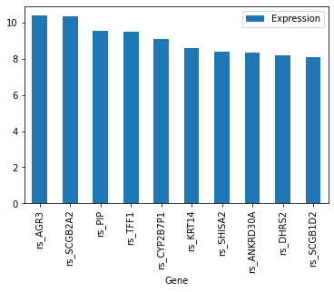

```python
brca_long = pd.melt(brca,  id_vars='PR.Status', var_name='Gene', value_name='Expression')
brca_long[brca_long['PR.Status']=='Positive'].groupby(
    'Gene').agg(np.mean).sort_values(
    'Expression',ascending=False).reset_index().iloc[:10].plot(
    kind='bar',x='Gene',y='Expression')
```

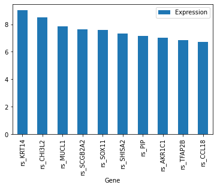

```python
brca_long[brca_long['PR.Status']=='Negative'].groupby(
    'Gene').agg(np.mean).sort_values(
    'Expression',ascending=False).reset_index().iloc[:10].plot(
    kind='bar',x='Gene',y='Expression')
```

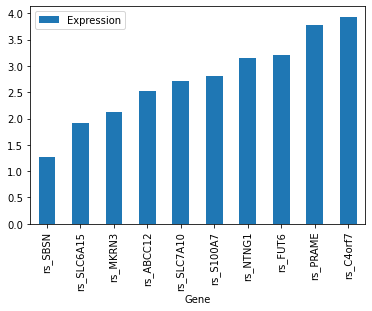

```python
brca_long[brca_long['PR.Status']=='Positive'].groupby(
    'Gene').agg(np.mean).sort_values(
    'Expression',ascending=True).reset_index().iloc[:10].plot(
    kind='bar',x='Gene',y='Expression')
```

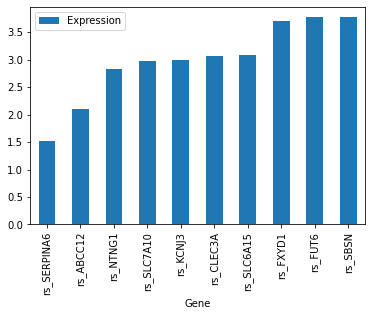

```python
brca_long[brca_long['PR.Status']=='Negative'].groupby(
    'Gene').agg(np.mean).sort_values(
    'Expression',ascending=True).reset_index().iloc[:10].plot(
    kind='bar',x='Gene',y='Expression')
```